# Basics of R

## Matrices

To construct a matrix from the scratch you need to use the `matrix()` operator. The first argument is the data that you want, the second argument is whether you want the values to fill the matrix by rows, the third argument is the number of rows.

**By row**

```r
m1 <- matrix(1:9, byrow = TRUE, nrow = 3)
m1
```

```
##      [,1] [,2] [,3]
## [1,]    1    2    3
## [2,]    4    5    6
## [3,]    7    8    9
```

**By Column**

```r
m2 <- matrix(1:9, byrow = FALSE, nrow = 3)
m2
```

```
##      [,1] [,2] [,3]
## [1,]    1    4    7
## [2,]    2    5    8
## [3,]    3    6    9
```

**If you have a series of vectors**

```r
new_vector <- c(numeric_vector, character_vector, logical_vector)
new_vector
```

```
##       a       b       c       d       e
##     "1"    "10"    "49"   "100"    "50"     "a"     "b"     "c"     "d"     "e"
##       A       B       C       D       E
##  "TRUE" "FALSE"  "TRUE"  "TRUE" "FALSE"
```

```r
m3 <- matrix(new_vector, nrow=5, byrow=FALSE)
m3
```

```
##      [,1]  [,2] [,3]
## [1,] "1"   "a"  "TRUE"
## [2,] "10"  "b"  "FALSE"
## [3,] "49"  "c"  "TRUE"
## [4,] "100" "d"  "TRUE"
## [5,] "50"  "e"  "FALSE"
```

Notice that since we have included vectors with different data types everything was converted to `strings`

Lets change the colum and row names using two different methods

```r
column_names <- c('Numbers','Letters','Logical')
row_names <- c('Subj1','Subj2','Subj3','Subj4','Subj5')

#Name the columns
colnames(m3) <- column_names


#Name the rows
rownames(m3) <- row_names

#Print the final matrix
m3
```

```
##       Numbers Letters Logical
## Subj1 "1"     "a"     "TRUE"
## Subj2 "10"    "b"     "FALSE"
## Subj3 "49"    "c"     "TRUE"
## Subj4 "100"   "d"     "TRUE"
## Subj5 "50"    "e"     "FALSE"
```

The code above named the columns and rows using vectors that contain the names but you can do it “manually” resulting in the same end product. We have modified it slightly to highlight that it is a different code.

```r
m3 <- matrix(c(numeric_vector, character_vector, logical_vector), nrow=5, byrow=FALSE, dimnames = list(c('a1','a2','a3','a4','a5'),c("numbers",'letters','logical')))
m3
```

```
##    numbers letters logical
## a1 "1"     "a"     "TRUE"
## a2 "10"    "b"     "FALSE"
## a3 "49"    "c"     "TRUE"
## a4 "100"   "d"     "TRUE"
## a5 "50"    "e"     "FALSE"
```

### Calculate by columns or rows.

This function calculates all of the columns or rows and stores the result on a different vector but they do have to be numeric. The code below is just for reference but if run, it will create errors since there are string and logical values.

*Note:* matrices can hold/contain ONLY ONE data type. If you want to change the data type of only one column transform to `dataframe` using `as.data.frame` and `as.matrix` commands.. See as.data.frame and as.matrix documentation for more details.

`number_colum_sum <- colSums(matrix_name)`. It adds by columns

`number_row_sum <- rowSums(matrix_name)`. It adds by rows

### Binding

You can bind by columns or by rows

**By Rows**

```r
rows_binded <- rbind(m3, numeric_vector)
rows_binded
```

```
##                numbers letters logical
## a1             "1"     "a"     "TRUE"
## a2             "10"    "b"     "FALSE"
## a3             "49"    "c"     "TRUE"
## a4             "100"   "d"     "TRUE"
## a5             "50"    "e"     "FALSE"
## numeric_vector "1"     "10"    "49"
```

As noted above the `numeric_vector` was added at the last row. Since in the example we combined a matrix and a vector the vector only places the amount of columns available. However if we bind two matrices all rows will be added.

```r
m_rbinded <- rbind(m3, m2)
m_rbinded
```

```
##    numbers letters logical
## a1 "1"     "a"     "TRUE"
## a2 "10"    "b"     "FALSE"
## a3 "49"    "c"     "TRUE"
## a4 "100"   "d"     "TRUE"
## a5 "50"    "e"     "FALSE"
##    "1"     "4"     "7"
##    "2"     "5"     "8"
##    "3"     "6"     "9"
```

**By Columns**

```r
m_cbinded <- cbind(m3, character_vector)
m_cbinded
```

```
##    numbers letters logical character_vector
## a1 "1"     "a"     "TRUE"  "a"
## a2 "10"    "b"     "FALSE" "b"
## a3 "49"    "c"     "TRUE"  "c"
## a4 "100"   "d"     "TRUE"  "d"
## a5 "50"    "e"     "FALSE" "e"
```

`cbind` Adds a column to the matrix.

*Note:* The vector or matrix binded on argument 2 needs to have the same amount of rows to be binded.

Select specific columns on a matrix

```r
logics <- m_cbinded[,3]
logics
```

```
##      a1      a2      a3      a4      a5
##  "TRUE" "FALSE"  "TRUE"  "TRUE" "FALSE"
```

Select specific rows from columns. In the case below we will select a2, a3 and a4 from the `Numeric_vector`.

We will take this opportunity to change the data types of the selected values from `string` to `numeric`. And to prove that the datatypes were indeed changed to numeric, we will perform mathematical operations on the extracted values.

```r
selected_numbers <- m_cbinded[2:4,1]
selected_numbers
```

```
##    a2    a3    a4
##  "10"  "49" "100"
```

```r
class(selected_numbers) <- "numeric"
mean(selected_numbers)
```

```
## [1] 53
```

```r
median(selected_numbers)
```

```
## [1] 49
```

Extracting all the rows from a specified column

```r
character_v <- m_cbinded[,4]
character_v
```

```
##  a1  a2  a3  a4  a5
## "a" "b" "c" "d" "e"
```

## Factors

Factors are the same as categories in `pandas`. Factors describe categorical variables.

To create factors in R, you make use of the function `factor()`. First, we will create a vector that contains all the observations that belong to the categories. In the example below we will create a sex_vector.

```r
sex_vector <- c("Male", "Female", "Female", "Male", "Male")
```

Now we let R konw that these are categories or factors

```r
sex_vector <-factor(sex_vector)
sex_vector
```

```
## [1] Male   Female Female Male   Male
## Levels: Female Male
```

```r
class(sex_vector)
```

```
## [1] "factor"
```

Although we created the factor in several steps, the same result can be achieved on a single line

```r
sex_vector <-factor(c("Male", "Female", "Female", "Male", "Male"))
class(sex_vector)
```

```
## [1] "factor"
```

Interestingly we can set the specific order or hierarchy (if the variable is ordinal) that our variable has.

```r
temperature <- factor(c('High', 'Low', 'High','Low','Medium'),order = TRUE, levels = c('Low','Medium','High'))
temperature
```

```
## [1] High   Low    High   Low    Medium
## Levels: Low < Medium < High
```

We can also let R assign the levels automaticcaly. However, it will do it alphabetically. However, it might not be conformant to what we want or need. We can change the order and content of the levels. To map `F` to `Female` and `M` to `Male` we use the `levels()` function

```r
sex <- factor(c('M','F','F','M','M'))
levels(sex)
```

```
## [1] "F" "M"
```

```r
sex
```

```
## [1] M F F M M
## Levels: F M
```

```r
levels(sex) <- c('Female','Male')
sex
```

```
## [1] Male   Female Female Male   Male
## Levels: Female Male
```

This is just to map the letter to the actual names. Note in the output the pre-specified levels were F and M thus to spell them out we need to specify them in the same order.

**Summarize factors**

```r
summary(sex)
```

```
## Female   Male
##      2      3
```

```r
summary(temperature)
```

```
##    Low Medium   High
##      2      1      2
```

# Higher order Data

## Data Frames

**Exploring data frames**

In the following section we will use one of the pre-loaded datasets. However, as the first step we will include the code to import `.csv` files to dataframes.

Similar to the `pd.read_csv` command in python, R studio has a `read.csv` command. Unlike python where the delimiter is passed through the function to read tab delimited files you need to use the `tab.delim` command. Use `?read.csv` and `?tab.delim` for more information.

`read.csv("file.name", stringsAsFactors = FALSE, headers = TRUE, sep = ',')`

To read the pre-loaded datasets just assign it to a variable or call it directly.

The first step to explore the data is to see the “structure” of the data. This command will give out the number of observations (rows) and the number of variables (columns) that the dataset has. Additionally, it will display the name and datatype of each variable

```r
str(mtcars)
```

```
## 'data.frame':    32 obs. of  11 variables:
##  $ mpg : num  21 21 22.8 21.4 18.7 18.1 14.3 24.4 22.8 19.2 ...
##  $ cyl : num  6 6 4 6 8 6 8 4 4 6 ...
##  $ disp: num  160 160 108 258 360 ...
##  $ hp  : num  110 110 93 110 175 105 245 62 95 123 ...
##  $ drat: num  3.9 3.9 3.85 3.08 3.15 2.76 3.21 3.69 3.92 3.92 ...
##  $ wt  : num  2.62 2.88 2.32 3.21 3.44 ...
##  $ qsec: num  16.5 17 18.6 19.4 17 ...
##  $ vs  : num  0 0 1 1 0 1 0 1 1 1 ...
##  $ am  : num  1 1 1 0 0 0 0 0 0 0 ...
##  $ gear: num  4 4 4 3 3 3 3 4 4 4 ...
##  $ carb: num  4 4 1 1 2 1 4 2 2 4 ...
```

**Summarize the data**

This command will display the basic statistics of each variable

```r
summary(mtcars)
```

```
##       mpg             cyl             disp             hp
##  Min.   :10.40   Min.   :4.000   Min.   : 71.1   Min.   : 52.0
##  1st Qu.:15.43   1st Qu.:4.000   1st Qu.:120.8   1st Qu.: 96.5
##  Median :19.20   Median :6.000   Median :196.3   Median :123.0
##  Mean   :20.09   Mean   :6.188   Mean   :230.7   Mean   :146.7
##  3rd Qu.:22.80   3rd Qu.:8.000   3rd Qu.:326.0   3rd Qu.:180.0
##  Max.   :33.90   Max.   :8.000   Max.   :472.0   Max.   :335.0
##       drat             wt             qsec             vs
##  Min.   :2.760   Min.   :1.513   Min.   :14.50   Min.   :0.0000
##  1st Qu.:3.080   1st Qu.:2.581   1st Qu.:16.89   1st Qu.:0.0000
##  Median :3.695   Median :3.325   Median :17.71   Median :0.0000
##  Mean   :3.597   Mean   :3.217   Mean   :17.85   Mean   :0.4375
##  3rd Qu.:3.920   3rd Qu.:3.610   3rd Qu.:18.90   3rd Qu.:1.0000
##  Max.   :4.930   Max.   :5.424   Max.   :22.90   Max.   :1.0000
##        am              gear            carb
##  Min.   :0.0000   Min.   :3.000   Min.   :1.000
##  1st Qu.:0.0000   1st Qu.:3.000   1st Qu.:2.000
##  Median :0.0000   Median :4.000   Median :2.000
##  Mean   :0.4062   Mean   :3.688   Mean   :2.812
##  3rd Qu.:1.0000   3rd Qu.:4.000   3rd Qu.:4.000
##  Max.   :1.0000   Max.   :5.000   Max.   :8.000
```

**Creating dataframes from the scratch***

```r
df <- data.frame(row_names, numeric_vector, character_vector, logical_vector, sex)
df
```

```
##   row_names numeric_vector character_vector logical_vector    sex
## a     Subj1              1                a           TRUE   Male
## b     Subj2             10                b          FALSE Female
## c     Subj3             49                c           TRUE Female
## d     Subj4            100                d           TRUE   Male
## e     Subj5             50                e          FALSE   Male
```

If you want you can explore the data as we did before notice that now we have factors and the leves are noted.

```r
str(df)
```

```
## 'data.frame':    5 obs. of  5 variables:
##  $ row_names       : chr  "Subj1" "Subj2" "Subj3" "Subj4" ...
##  $ numeric_vector  : num  1 10 49 100 50
##  $ character_vector: chr  "a" "b" "c" "d" ...
##  $ logical_vector  : logi  TRUE FALSE TRUE TRUE FALSE
##  $ sex             : Factor w/ 2 levels "Female","Male": 2 1 1 2 2
```

```r
summary(df)
```

```
##   row_names         numeric_vector character_vector   logical_vector
##  Length:5           Min.   :  1    Length:5           Mode :logical
##  Class :character   1st Qu.: 10    Class :character   FALSE:2
##  Mode  :character   Median : 49    Mode  :character   TRUE :3
##                     Mean   : 42
##                     3rd Qu.: 50
##                     Max.   :100
##      sex
##  Female:2
##  Male  :3
##
##
##
##
```

Similarly as we did with matrices, we can extract specific values from dataframes. We will work with the preloaded daaframe

**Extracts row 1 column 3**

```r
mtcars[1,3]
```

```
## [1] 160
```

**Extracts the whole fourth row (Hornet 4 Drive)**

```r
mtcars[4,]
```

```
##                 mpg cyl disp  hp drat    wt  qsec vs am gear carb
## Hornet 4 Drive 21.4   6  258 110 3.08 3.215 19.44  1  0    3    1
```

**Extracts the entire column 3 (disp)**

```r
mtcars[,3]
```

```
##  [1] 160.0 160.0 108.0 258.0 360.0 225.0 360.0 146.7 140.8 167.6 167.6 275.8
## [13] 275.8 275.8 472.0 460.0 440.0  78.7  75.7  71.1 120.1 318.0 304.0 350.0
## [25] 400.0  79.0 120.3  95.1 351.0 145.0 301.0 121.0
```

**Select the first 3 values of the WT column**

```r
mtcars[1:3,'wt']
```

```
## [1] 2.620 2.875 2.320
```

Just as before this is for exploration purposes but we can assign those values to variables. Select the `wt` variable and assign it to a variable. To specify the column we will use the `$` symbol. This is the equivalent to `mtcars.wt` or `mtcars['wt']` in Python

```r
wt <- mtcars$wt
wt
```

```
##  [1] 2.620 2.875 2.320 3.215 3.440 3.460 3.570 3.190 3.150 3.440 3.440 4.070
## [13] 3.730 3.780 5.250 5.424 5.345 2.200 1.615 1.835 2.465 3.520 3.435 3.840
## [25] 3.845 1.935 2.140 1.513 3.170 2.770 3.570 2.780
```

The difference between python and R is that once the variable is extracted from the dataframe it “looses” its visual format and now the rows are shown next to eachother.

### Filtering data

After creating a boolean vector we can use it to filter the data. In the example below we will extract those cars with less than 21 mpg and create a new filtered dataframe. Notice that you can select the mpg column in three different ways:

1. `mtcars$mpg` (displayed below)
2. `mtcars[,mpg]`
3. `mtcars[,1]`

```r
efficiency_vector <- mtcars$mpg < 21
# Now we tell R to check every row where `efficiency_vector==TRUE`
efficient_cars <- mtcars[efficiency_vector,]
efficient_cars
```

```
##                      mpg cyl  disp  hp drat    wt  qsec vs am gear carb
## Hornet Sportabout   18.7   8 360.0 175 3.15 3.440 17.02  0  0    3    2
## Valiant             18.1   6 225.0 105 2.76 3.460 20.22  1  0    3    1
## Duster 360          14.3   8 360.0 245 3.21 3.570 15.84  0  0    3    4
## Merc 280            19.2   6 167.6 123 3.92 3.440 18.30  1  0    4    4
## Merc 280C           17.8   6 167.6 123 3.92 3.440 18.90  1  0    4    4
## Merc 450SE          16.4   8 275.8 180 3.07 4.070 17.40  0  0    3    3
## Merc 450SL          17.3   8 275.8 180 3.07 3.730 17.60  0  0    3    3
## Merc 450SLC         15.2   8 275.8 180 3.07 3.780 18.00  0  0    3    3
## Cadillac Fleetwood  10.4   8 472.0 205 2.93 5.250 17.98  0  0    3    4
## Lincoln Continental 10.4   8 460.0 215 3.00 5.424 17.82  0  0    3    4
## Chrysler Imperial   14.7   8 440.0 230 3.23 5.345 17.42  0  0    3    4
## Dodge Challenger    15.5   8 318.0 150 2.76 3.520 16.87  0  0    3    2
## AMC Javelin         15.2   8 304.0 150 3.15 3.435 17.30  0  0    3    2
## Camaro Z28          13.3   8 350.0 245 3.73 3.840 15.41  0  0    3    4
## Pontiac Firebird    19.2   8 400.0 175 3.08 3.845 17.05  0  0    3    2
## Ford Pantera L      15.8   8 351.0 264 4.22 3.170 14.50  0  1    5    4
## Ferrari Dino        19.7   6 145.0 175 3.62 2.770 15.50  0  1    5    6
## Maserati Bora       15.0   8 301.0 335 3.54 3.570 14.60  0  1    5    8
```

Another way to filter a dataframe is using the `subset` function

```r
subset(mtcars, subset = mpg < 21)
```

```
##                      mpg cyl  disp  hp drat    wt  qsec vs am gear carb
## Hornet Sportabout   18.7   8 360.0 175 3.15 3.440 17.02  0  0    3    2
## Valiant             18.1   6 225.0 105 2.76 3.460 20.22  1  0    3    1
## Duster 360          14.3   8 360.0 245 3.21 3.570 15.84  0  0    3    4
## Merc 280            19.2   6 167.6 123 3.92 3.440 18.30  1  0    4    4
## Merc 280C           17.8   6 167.6 123 3.92 3.440 18.90  1  0    4    4
## Merc 450SE          16.4   8 275.8 180 3.07 4.070 17.40  0  0    3    3
## Merc 450SL          17.3   8 275.8 180 3.07 3.730 17.60  0  0    3    3
## Merc 450SLC         15.2   8 275.8 180 3.07 3.780 18.00  0  0    3    3
## Cadillac Fleetwood  10.4   8 472.0 205 2.93 5.250 17.98  0  0    3    4
## Lincoln Continental 10.4   8 460.0 215 3.00 5.424 17.82  0  0    3    4
## Chrysler Imperial   14.7   8 440.0 230 3.23 5.345 17.42  0  0    3    4
## Dodge Challenger    15.5   8 318.0 150 2.76 3.520 16.87  0  0    3    2
## AMC Javelin         15.2   8 304.0 150 3.15 3.435 17.30  0  0    3    2
## Camaro Z28          13.3   8 350.0 245 3.73 3.840 15.41  0  0    3    4
## Pontiac Firebird    19.2   8 400.0 175 3.08 3.845 17.05  0  0    3    2
## Ford Pantera L      15.8   8 351.0 264 4.22 3.170 14.50  0  1    5    4
## Ferrari Dino        19.7   6 145.0 175 3.62 2.770 15.50  0  1    5    6
## Maserati Bora       15.0   8 301.0 335 3.54 3.570 14.60  0  1    5    8
```

You can subset with strings or logical variables as well

```r
subset(df, subset = sex == 'Male')
```

```
##   row_names numeric_vector character_vector logical_vector  sex
## a     Subj1              1                a           TRUE Male
## d     Subj4            100                d           TRUE Male
## e     Subj5             50                e          FALSE Male
```

Similarly to the vectors we can order a whole dataframe based on a variable

```r
wt_order <- order(mtcars$wt)
wt_order
```

```
##  [1] 28 19 20 26 27 18  3 21  1 30 32  2  9 29  8  4 23  5 10 11  6 22  7 31 13
## [26] 14 24 25 12 15 17 16
```

```r
wt_ordered <- mtcars[wt_order,]
wt_ordered
```

```
##                      mpg cyl  disp  hp drat    wt  qsec vs am gear carb
## Lotus Europa        30.4   4  95.1 113 3.77 1.513 16.90  1  1    5    2
## Honda Civic         30.4   4  75.7  52 4.93 1.615 18.52  1  1    4    2
## Toyota Corolla      33.9   4  71.1  65 4.22 1.835 19.90  1  1    4    1
## Fiat X1-9           27.3   4  79.0  66 4.08 1.935 18.90  1  1    4    1
## Porsche 914-2       26.0   4 120.3  91 4.43 2.140 16.70  0  1    5    2
## Fiat 128            32.4   4  78.7  66 4.08 2.200 19.47  1  1    4    1
## Datsun 710          22.8   4 108.0  93 3.85 2.320 18.61  1  1    4    1
## Toyota Corona       21.5   4 120.1  97 3.70 2.465 20.01  1  0    3    1
## Mazda RX4           21.0   6 160.0 110 3.90 2.620 16.46  0  1    4    4
## Ferrari Dino        19.7   6 145.0 175 3.62 2.770 15.50  0  1    5    6
## Volvo 142E          21.4   4 121.0 109 4.11 2.780 18.60  1  1    4    2
## Mazda RX4 Wag       21.0   6 160.0 110 3.90 2.875 17.02  0  1    4    4
## Merc 230            22.8   4 140.8  95 3.92 3.150 22.90  1  0    4    2
## Ford Pantera L      15.8   8 351.0 264 4.22 3.170 14.50  0  1    5    4
## Merc 240D           24.4   4 146.7  62 3.69 3.190 20.00  1  0    4    2
## Hornet 4 Drive      21.4   6 258.0 110 3.08 3.215 19.44  1  0    3    1
## AMC Javelin         15.2   8 304.0 150 3.15 3.435 17.30  0  0    3    2
## Hornet Sportabout   18.7   8 360.0 175 3.15 3.440 17.02  0  0    3    2
## Merc 280            19.2   6 167.6 123 3.92 3.440 18.30  1  0    4    4
## Merc 280C           17.8   6 167.6 123 3.92 3.440 18.90  1  0    4    4
## Valiant             18.1   6 225.0 105 2.76 3.460 20.22  1  0    3    1
## Dodge Challenger    15.5   8 318.0 150 2.76 3.520 16.87  0  0    3    2
## Duster 360          14.3   8 360.0 245 3.21 3.570 15.84  0  0    3    4
## Maserati Bora       15.0   8 301.0 335 3.54 3.570 14.60  0  1    5    8
## Merc 450SL          17.3   8 275.8 180 3.07 3.730 17.60  0  0    3    3
## Merc 450SLC         15.2   8 275.8 180 3.07 3.780 18.00  0  0    3    3
## Camaro Z28          13.3   8 350.0 245 3.73 3.840 15.41  0  0    3    4
## Pontiac Firebird    19.2   8 400.0 175 3.08 3.845 17.05  0  0    3    2
## Merc 450SE          16.4   8 275.8 180 3.07 4.070 17.40  0  0    3    3
## Cadillac Fleetwood  10.4   8 472.0 205 2.93 5.250 17.98  0  0    3    4
## Chrysler Imperial   14.7   8 440.0 230 3.23 5.345 17.42  0  0    3    4
## Lincoln Continental 10.4   8 460.0 215 3.00 5.424 17.82  0  0    3    4
```

## Lists

A list differs from python in the sense that it can store multiple types of data. In that way it is more similar to dictionaries in python or [Mongodb](https://www.mongodb.com/).

In the example below we are creating a list with vectors, matrices and dataframes. Notice that when the list is called the “item number” is noted between two brackets `[[n]]`

```r
my_list <- list(numeric_vector, m3, df)
my_list
```

```
## [[1]]
##   a   b   c   d   e
##   1  10  49 100  50
##
## [[2]]
##    numbers letters logical
## a1 "1"     "a"     "TRUE"
## a2 "10"    "b"     "FALSE"
## a3 "49"    "c"     "TRUE"
## a4 "100"   "d"     "TRUE"
## a5 "50"    "e"     "FALSE"
##
## [[3]]
##   row_names numeric_vector character_vector logical_vector    sex
## a     Subj1              1                a           TRUE   Male
## b     Subj2             10                b          FALSE Female
## c     Subj3             49                c           TRUE Female
## d     Subj4            100                d           TRUE   Male
## e     Subj5             50                e          FALSE   Male
```

We can name each one of the items for easy identification. Note that now, the item changed to `$Name`

```r
names(my_list) <- c('Numeric vector','Matrix','Custom dataframe')
my_list
```

```
## $`Numeric vector`
##   a   b   c   d   e
##   1  10  49 100  50
##
## $Matrix
##    numbers letters logical
## a1 "1"     "a"     "TRUE"
## a2 "10"    "b"     "FALSE"
## a3 "49"    "c"     "TRUE"
## a4 "100"   "d"     "TRUE"
## a5 "50"    "e"     "FALSE"
##
## $`Custom dataframe`
##   row_names numeric_vector character_vector logical_vector    sex
## a     Subj1              1                a           TRUE   Male
## b     Subj2             10                b          FALSE Female
## c     Subj3             49                c           TRUE Female
## d     Subj4            100                d           TRUE   Male
## e     Subj5             50                e          FALSE   Male
```

To ilustrate how lists are similar to `dict` in pyton we will create a ‘movie’ list.

```r
mov <- 'The shining'
act <- c('Jack Nicholson','Shelley Duval','Danny Lloyd','Scatman Crothers','Barry Nelson')
scores <- c(4.5,4.0,5.0)
sources <- c('IMDb1','IMDb2','IMDb3')
comments <- c('Best Horror Film I have Ever seen','A truly brilliant and scary film from SK','A masterpiece of psychological horror')
rev <- data.frame(scores, sources, comments)

shining_list <- list(moviename = mov, actors = act, reviews = rev)
shining_list
```

```
## $moviename
## [1] "The shining"
##
## $actors
## [1] "Jack Nicholson"   "Shelley Duval"    "Danny Lloyd"      "Scatman Crothers"
## [5] "Barry Nelson"
##
## $reviews
##   scores sources                                 comments
## 1    4.5   IMDb1        Best Horror Film I have Ever seen
## 2    4.0   IMDb2 A truly brilliant and scary film from SK
## 3    5.0   IMDb3    A masterpiece of psychological horror
```

As seen above, this list would be equivalent to `dict = {'Movies':mov, 'actors':act,'reviews':rev}` in python.

Similar to python we can extract or parse the values of a list using fairly similar syntax

```r
shining_list[['actors']]
```

```
## [1] "Jack Nicholson"   "Shelley Duval"    "Danny Lloyd"      "Scatman Crothers"
## [5] "Barry Nelson"
```

```r
#Produces the same output as:
shining_list$actors
```

```
## [1] "Jack Nicholson"   "Shelley Duval"    "Danny Lloyd"      "Scatman Crothers"
## [5] "Barry Nelson"
```

However to extract a specific item from the list pay attention to the placement of the square brackets. Example: extract the second actor from the second item in the list (‘actors’)

```r
shining_list[[2]][2]
```

```
## [1] "Shelley Duval"
```

This is helpful to know in case you want to perform operations with lists. However, you need to be careful with the kind of data that you are performing such operations.

In the example below we parse the shining_list to extract the `scores` from the `reviews` data frame. But, when this is extracted it is not changed to vector, rather it stays in the original data type, in this case, dataframe. Thus, eventhough it is a single column of `doubles` or `floats` when performing the `mean` operation we need to treat that variable as an entire new dataframe and include the notation: * `mean (df$df)` OR * `mean(df[,])`

```r
scores <- shining_list[['reviews']]['scores']
avg_score <- mean(scores$scores)
avg_score
```

```
## [1] 4.5
```

## Contingecy tables

Contingency tables are tables that show relationships between data. They are a great starting point to explore data, usually categorical. Now we will use the superheroes database for a variety of reasons. One of them is that is not a pre-loaded data and it takes a few lines of code to get it and prepare it. Thus, it is a good opportunity to code a little higher level chunk of code. The code can be found [here](https://www.rdocumentation.org/packages/fivethirtyeight/versions/0.5.0/topics/comic_characters)

```r
#Get the DC characters
dc_characters <-  "https://github.com/fivethirtyeight/data/raw/master/comic-characters/dc-wikia-data.csv" %>%
  read_csv() %>%
  clean_names() %>%
  mutate(publisher = "DC")

#Marvel characters
marvel_characters <- "https://github.com/fivethirtyeight/data/raw/master/comic-characters/marvel-wikia-data.csv" %>%
  read_csv() %>%
  clean_names() %>%
  mutate(publisher = "Marvel")

# Merging datasets

comics <-
  dc_characters %>%
  bind_rows(marvel_characters) %>%
  separate(first_appearance, c("year2", "month"), ", ", remove = FALSE) %>%
  mutate(
    # If month was missing, set as January and day as 01:
    month = ifelse(is.na(month), "01", month),
    day = "01",
    # Note some years missing:
    date = ymd(paste(year, month, day, sep = "-")),
    align = factor(
      align,
      levels = c("Bad Characters", "Reformed Criminals", "Netural Characters", "Good Characters"),
      ordered = TRUE)
  ) %>%
  select(publisher, everything(), -c(year2, day))
```

After merging the data we need to clean up a little bit. Specifically, we will change numerous columns to factors. In order to do that, we first create a vector with the column names that we want to modify. Following, we apply `factor` function and check the data and the levels

```r
str(comics)
```

```
## tibble [23,272 x 16] (S3: tbl_df/tbl/data.frame)
##  $ publisher       : chr [1:23272] "DC" "DC" "DC" "DC" ...
##  $ page_id         : num [1:23272] 1422 23387 1458 1659 1576 ...
##  $ name            : chr [1:23272] "Batman (Bruce Wayne)" "Superman (Clark Kent)" "Green Lantern (Hal Jordan)" "James Gordon (New Earth)" ...
##  $ urlslug         : chr [1:23272] "\\/wiki\\/Batman_(Bruce_Wayne)" "\\/wiki\\/Superman_(Clark_Kent)" "\\/wiki\\/Green_Lantern_(Hal_Jordan)" "\\/wiki\\/James_Gordon_(New_Earth)" ...
##  $ id              : chr [1:23272] "Secret Identity" "Secret Identity" "Secret Identity" "Public Identity" ...
##  $ align           : Ord.factor w/ 4 levels "Bad Characters"<..: 4 4 4 4 4 4 4 4 4 4 ...
##  $ eye             : chr [1:23272] "Blue Eyes" "Blue Eyes" "Brown Eyes" "Brown Eyes" ...
##  $ hair            : chr [1:23272] "Black Hair" "Black Hair" "Brown Hair" "White Hair" ...
##  $ sex             : chr [1:23272] "Male Characters" "Male Characters" "Male Characters" "Male Characters" ...
##  $ gsm             : chr [1:23272] NA NA NA NA ...
##  $ alive           : chr [1:23272] "Living Characters" "Living Characters" "Living Characters" "Living Characters" ...
##  $ appearances     : num [1:23272] 3093 2496 1565 1316 1237 ...
##  $ first_appearance: chr [1:23272] "1939, May" "1986, October" "1959, October" "1987, February" ...
##  $ month           : chr [1:23272] "May" "October" "October" "February" ...
##  $ year            : num [1:23272] 1939 1986 1959 1987 1940 ...
##  $ date            : Date[1:23272], format: "1939-05-01" "1986-10-01" ...
```

```r
head(comics)
```

```
## # A tibble: 6 x 16
##   publisher page_id name  urlslug id    align eye   hair  sex   gsm   alive
##   <chr>       <dbl> <chr> <chr>   <chr> <ord> <chr> <chr> <chr> <chr> <chr>
## 1 DC           1422 Batm~ "\\/wi~ Secr~ Good~ Blue~ Blac~ Male~ <NA>  Livi~
## 2 DC          23387 Supe~ "\\/wi~ Secr~ Good~ Blue~ Blac~ Male~ <NA>  Livi~
## 3 DC           1458 Gree~ "\\/wi~ Secr~ Good~ Brow~ Brow~ Male~ <NA>  Livi~
## 4 DC           1659 Jame~ "\\/wi~ Publ~ Good~ Brow~ Whit~ Male~ <NA>  Livi~
## 5 DC           1576 Rich~ "\\/wi~ Secr~ Good~ Blue~ Blac~ Male~ <NA>  Livi~
## 6 DC           1448 Wond~ "\\/wi~ Publ~ Good~ Blue~ Blac~ Fema~ <NA>  Livi~
## # ... with 5 more variables: appearances <dbl>, first_appearance <chr>,
## #   month <chr>, year <dbl>, date <date>
```

```r
col_names <- c('eye', 'hair', 'sex', 'alive')
comics[col_names] <- lapply(comics[col_names],factor)
levels(comics$eye)
```

```
##  [1] "Amber Eyes"         "Auburn Hair"        "Black Eyeballs"
##  [4] "Black Eyes"         "Blue Eyes"          "Brown Eyes"
##  [7] "Compound Eyes"      "Gold Eyes"          "Green Eyes"
## [10] "Grey Eyes"          "Hazel Eyes"         "Magenta Eyes"
## [13] "Multiple Eyes"      "No Eyes"            "One Eye"
## [16] "Orange Eyes"        "Photocellular Eyes" "Pink Eyes"
## [19] "Purple Eyes"        "Red Eyes"           "Silver Eyes"
## [22] "Variable Eyes"      "Violet Eyes"        "White Eyes"
## [25] "Yellow Eyeballs"    "Yellow Eyes"
```

Now we can create some contingency tables to look for correlations

```r
table(comics$sex,comics$align)
```

```
##
##                          Bad Characters Reformed Criminals Netural Characters
##   Agender Characters                 20                  0                  0
##   Female Characters                1573                  1                  0
##   Genderfluid Characters              0                  0                  0
##   Genderless Characters              11                  0                  0
##   Male Characters                  7561                  2                  0
##   Transgender Characters              1                  0                  0
##
##                          Good Characters
##   Agender Characters                  10
##   Female Characters                 2490
##   Genderfluid Characters               1
##   Genderless Characters                6
##   Male Characters                   4809
##   Transgender Characters               0
```

It seems that we don’t have some factors with low counts which probably will not add much to our analysis and are adding an extra level to the current structure. We are going to drop some factors and “fuse” other ones. For example in the `sex` variable we have two genders that can be consider as one: ‘Agender’ and ’Genderless. The first block of code is to exclude specific factors. Notice that it was used the opperand `!=` meaning we want every other character that do not meet these conditions. Additionally, unlike python were we can use the `OR` opperand (`|` in R), here we need to be more explicit in our conditions.

```r
library(forcats)
comics_filtered <- comics %>%
  filter(align != 'Reformed Criminals', align !='Neutral Characters',
         sex != 'Genderfluid Characters', sex!= 'Transgender Characters') %>%
  droplevels()
levels(comics_filtered$sex)
```

```
## [1] "Agender Characters"    "Female Characters"     "Genderless Characters"
## [4] "Male Characters"
```

Now, we want to combine factors into one using the `fct_collapse` function. it takes the following arguments: data, new vector name = c(variables to be combined).

Notice that the syntax to select a column below is very similar to python where we would write `comics_filtered` **=** *function* . The only difference is the symbol to assign the variable.

After passing this function we check with our contingency table the results of our filter and factor combination.

```r
comics_filtered['sex'] <- fct_collapse(comics_filtered$sex,
                                       Genderless = c('Agender Characters','Genderless Characters'))

table(comics_filtered$sex, comics_filtered$align)
```

```
##
##                     Bad Characters Good Characters
##   Genderless                    31              16
##   Female Characters           1573            2490
##   Male Characters             7561            4809
```

**UP NEXT: Visualization in R**

Althought, we will have a separate section on data visualization. Here is a visual glimpse on how the data that we have manipulated so far would look like.

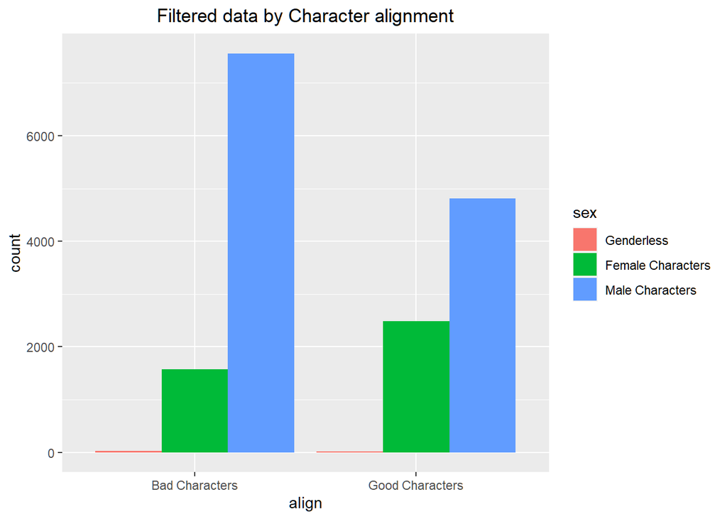

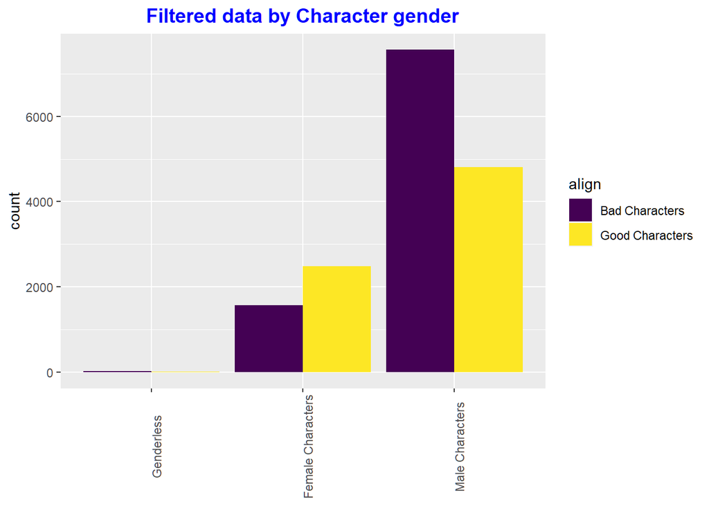

#### [< Back Home](https://eduardorod1229.github.io/Data-science-pages/) [Python in R >](https://eduardorod1229.github.io/Data-science-pages/How-to-use-python-in-R.html)